# Red Wine Data Analysis by Marco Rizk

> The “red wine quality” dataset explores the chemical factors affecting wine  
> quality as represented by different taste experts.

# Univariate Plots Section

```
## 'data.frame':    1599 obs. of  13 variables:
##  $ X                   : int  1 2 3 4 5 6 7 8 9 10 ...
##  $ fixed.acidity       : num  7.4 7.8 7.8 11.2 7.4 7.4 7.9 7.3 7.8 7.5 ...
##  $ volatile.acidity    : num  0.7 0.88 0.76 0.28 0.7 0.66 0.6 0.65 0.58 0.5 ...
##  $ citric.acid         : num  0 0 0.04 0.56 0 0 0.06 0 0.02 0.36 ...
##  $ residual.sugar      : num  1.9 2.6 2.3 1.9 1.9 1.8 1.6 1.2 2 6.1 ...
##  $ chlorides           : num  0.076 0.098 0.092 0.075 0.076 0.075 0.069 0.065 0.073 0.071 ...
##  $ free.sulfur.dioxide : num  11 25 15 17 11 13 15 15 9 17 ...
##  $ total.sulfur.dioxide: num  34 67 54 60 34 40 59 21 18 102 ...
##  $ density             : num  0.998 0.997 0.997 0.998 0.998 ...
##  $ pH                  : num  3.51 3.2 3.26 3.16 3.51 3.51 3.3 3.39 3.36 3.35 ...
##  $ sulphates           : num  0.56 0.68 0.65 0.58 0.56 0.56 0.46 0.47 0.57 0.8 ...
##  $ alcohol             : num  9.4 9.8 9.8 9.8 9.4 9.4 9.4 10 9.5 10.5 ...
##  $ quality             : int  5 5 5 6 5 5 5 7 7 5 ...
```

```
##        X          fixed.acidity   volatile.acidity  citric.acid
##  Min.   :   1.0   Min.   : 4.60   Min.   :0.1200   Min.   :0.000
##  1st Qu.: 400.5   1st Qu.: 7.10   1st Qu.:0.3900   1st Qu.:0.090
##  Median : 800.0   Median : 7.90   Median :0.5200   Median :0.260
##  Mean   : 800.0   Mean   : 8.32   Mean   :0.5278   Mean   :0.271
##  3rd Qu.:1199.5   3rd Qu.: 9.20   3rd Qu.:0.6400   3rd Qu.:0.420
##  Max.   :1599.0   Max.   :15.90   Max.   :1.5800   Max.   :1.000
##  residual.sugar     chlorides       free.sulfur.dioxide
##  Min.   : 0.900   Min.   :0.01200   Min.   : 1.00
##  1st Qu.: 1.900   1st Qu.:0.07000   1st Qu.: 7.00
##  Median : 2.200   Median :0.07900   Median :14.00
##  Mean   : 2.539   Mean   :0.08747   Mean   :15.87
##  3rd Qu.: 2.600   3rd Qu.:0.09000   3rd Qu.:21.00
##  Max.   :15.500   Max.   :0.61100   Max.   :72.00
##  total.sulfur.dioxide    density             pH          sulphates
##  Min.   :  6.00       Min.   :0.9901   Min.   :2.740   Min.   :0.3300
##  1st Qu.: 22.00       1st Qu.:0.9956   1st Qu.:3.210   1st Qu.:0.5500
##  Median : 38.00       Median :0.9968   Median :3.310   Median :0.6200
##  Mean   : 46.47       Mean   :0.9967   Mean   :3.311   Mean   :0.6581
##  3rd Qu.: 62.00       3rd Qu.:0.9978   3rd Qu.:3.400   3rd Qu.:0.7300
##  Max.   :289.00       Max.   :1.0037   Max.   :4.010   Max.   :2.0000
##     alcohol         quality
##  Min.   : 8.40   Min.   :3.000
##  1st Qu.: 9.50   1st Qu.:5.000
##  Median :10.20   Median :6.000
##  Mean   :10.42   Mean   :5.636
##  3rd Qu.:11.10   3rd Qu.:6.000
##  Max.   :14.90   Max.   :8.000
```

```
##   X fixed.acidity volatile.acidity citric.acid residual.sugar chlorides
## 1 1           7.4             0.70        0.00            1.9     0.076
## 2 2           7.8             0.88        0.00            2.6     0.098
## 3 3           7.8             0.76        0.04            2.3     0.092
## 4 4          11.2             0.28        0.56            1.9     0.075
## 5 5           7.4             0.70        0.00            1.9     0.076
## 6 6           7.4             0.66        0.00            1.8     0.075
##   free.sulfur.dioxide total.sulfur.dioxide density   pH sulphates alcohol
## 1                  11                   34  0.9978 3.51      0.56     9.4
## 2                  25                   67  0.9968 3.20      0.68     9.8
## 3                  15                   54  0.9970 3.26      0.65     9.8
## 4                  17                   60  0.9980 3.16      0.58     9.8
## 5                  11                   34  0.9978 3.51      0.56     9.4
## 6                  13                   40  0.9978 3.51      0.56     9.4
##   quality
## 1       5
## 2       5
## 3       5
## 4       6
## 5       5
## 6       5
```

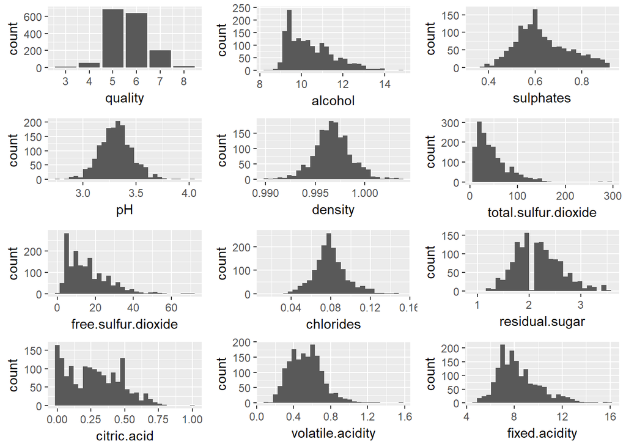

# comments on plots

# Univariate Analysis

### What is the structure of your dataset?

The dataset consists of 1599 obsevations, structured into a 13 variable table  
which are: Sample no. , fixed acidity, volatile acitdity, citric acid, residual sugar,  
chlorides, free sulfur oxide , total sulfur oxide, density, pH, sulphates,  
alcohol, quality.

### What is/are the main feature(s) of interest in your dataset?

The main feature is “quality”. we need to investigate what factors affect  
the quality

### What other features in the dataset do you think will help support your investigation into your feature(s) of interest?

putting the chlorides and residual sugar aside. I think acidity has rhe major  
effect on qulaity (whether fixed or volatile) which would refect on pH too  
Also we need to investigate how different acids affect quality.

### Did you create any new variables from existing variables in the dataset?

No the exisitng variables are sufficent for the investigation.

### Of the features you investigated, were there any unusual distributions? Did you perform any operations on the data to tidy, adjust, or change the form of the data? If so, why did you do this?

# Bivariate Plots Section

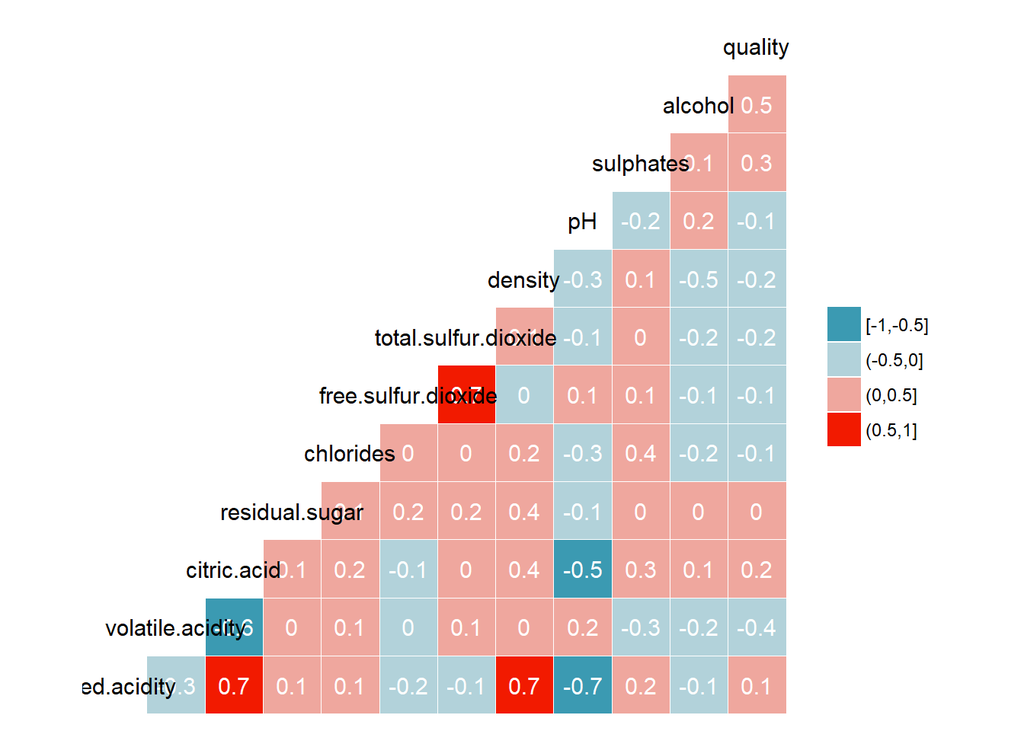

# Observations:

1. The factor affecting quality are: alcohol, volatile acidity(negatively)  
   and sulphates
2. Alcohol is negatively correlated with denisty which is normal to expect
3. Sulphates are correlated with chlorides
4. pH is negatively correlated with fixed acidity whis is expected as lower  
   pH indicates higher acidity
5. density is correlated with fixed acidity
6. citric acid is correlated with acidity

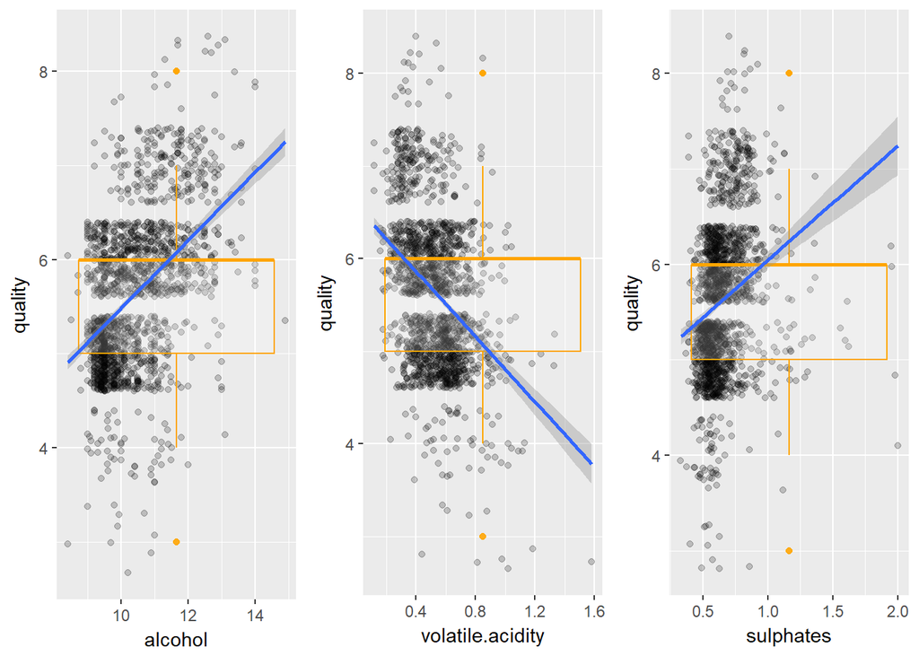

# Bivariate Analysis

### Talk about some of the relationships you observed in this part of the investigation. How did the feature(s) of interest vary with other features in the dataset?

The factors that affect the quality the most are Alcohol and Volatile acidity  
and sulphates

### Did you observe any interesting relationships between the other features (not the main feature(s) of interest)?

1. Fixed acidity and pH are negatively correlated which is expected as lower  
   pH indicates higher acidity
2. Also Fixed acidity is strongly correlated to density
3. Alcohol and density are negatively correlated which is expected

### What was the strongest relationship you found?

The strongest was between density and fixed acidity

# Multivariate Plots Section

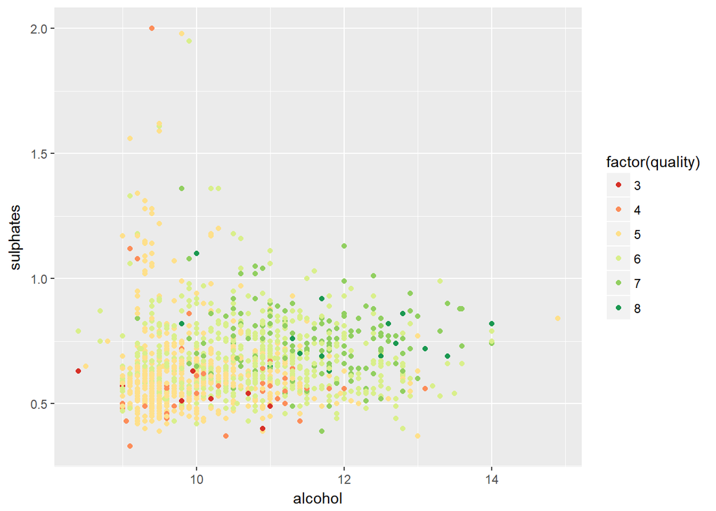

It can be observed that best quality wines are those of high alcohol content  
and sulphates between 0.5 and 1

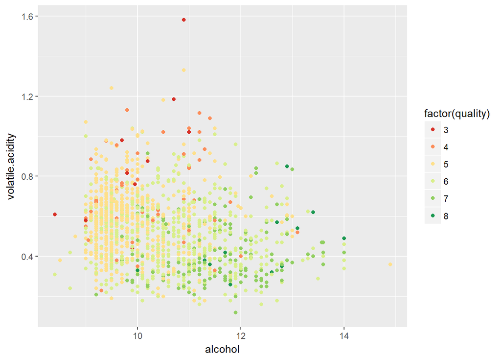

Another observation would be that higher quality wine are the ones associated  
with higher alcohol content and voaltile acidity less than nearly 0.6

```
##
## Calls:
## m1: lm(formula = I(quality) ~ I(alcohol), data = red_wine)
## m2: lm(formula = I(quality) ~ I(alcohol) + volatile.acidity, data = red_wine)
## m3: lm(formula = I(quality) ~ I(alcohol) + volatile.acidity + log10(sulphates),
##     data = red_wine)
## m4: lm(formula = I(quality) ~ I(alcohol) + volatile.acidity + log10(sulphates) +
##     log10(chlorides), data = red_wine)
## m5: lm(formula = I(quality) ~ I(alcohol) + volatile.acidity + log10(sulphates) +
##     log10(chlorides) + pH, data = red_wine)
## m6: lm(formula = I(quality) ~ I(alcohol) + volatile.acidity + log10(sulphates) +
##     log10(chlorides) + pH + citric.acid, data = red_wine)
##
## ========================================================================================================
##                          m1            m2            m3            m4            m5            m6
## --------------------------------------------------------------------------------------------------------
##   (Intercept)           1.875***      3.095***      3.369***      3.069***      4.225***      4.842***
##                        (0.175)       (0.184)       (0.184)       (0.199)       (0.360)       (0.449)
##   I(alcohol)            0.361***      0.314***      0.303***      0.282***      0.295***      0.302***
##                        (0.017)       (0.016)       (0.016)       (0.017)       (0.017)       (0.017)
##   volatile.acidity                   -1.384***     -1.156***     -1.100***     -0.987***     -1.110***
##                                      (0.095)       (0.097)       (0.098)       (0.102)       (0.115)
##   log10(sulphates)                                  1.477***      1.713***      1.690***      1.742***
##                                                    (0.177)       (0.187)       (0.186)       (0.187)
##   log10(chlorides)                                               -0.491***     -0.612***     -0.564***
##                                                                  (0.128)       (0.131)       (0.132)
##   pH                                                                           -0.448***     -0.595***
##                                                                                (0.116)       (0.133)
##   citric.acid                                                                                -0.276*
##                                                                                              (0.121)
## --------------------------------------------------------------------------------------------------------
##   R-squared             0.227         0.317         0.345         0.352         0.357         0.360
##   adj. R-squared        0.226         0.316         0.344         0.350         0.355         0.357
##   sigma                 0.710         0.668         0.654         0.651         0.648         0.647
##   F                   468.267       370.379       280.646       216.010       177.270       148.984
##   p                     0.000         0.000         0.000         0.000         0.000         0.000
##   Log-likelihood    -1721.057     -1621.814     -1587.752     -1580.357     -1572.954     -1570.342
##   Deviance            805.870       711.796       682.108       675.828       669.599       667.415
##   AIC                3448.114      3251.628      3185.503      3172.714      3159.908      3156.683
##   BIC                3464.245      3273.136      3212.389      3204.977      3197.548      3199.700
##   N                  1599          1599          1599          1599          1599          1599
## ========================================================================================================
```

# Multivariate Analysis

### Were there any interesting or surprising interactions between features?

# Final Plots and Summary

### Plot One

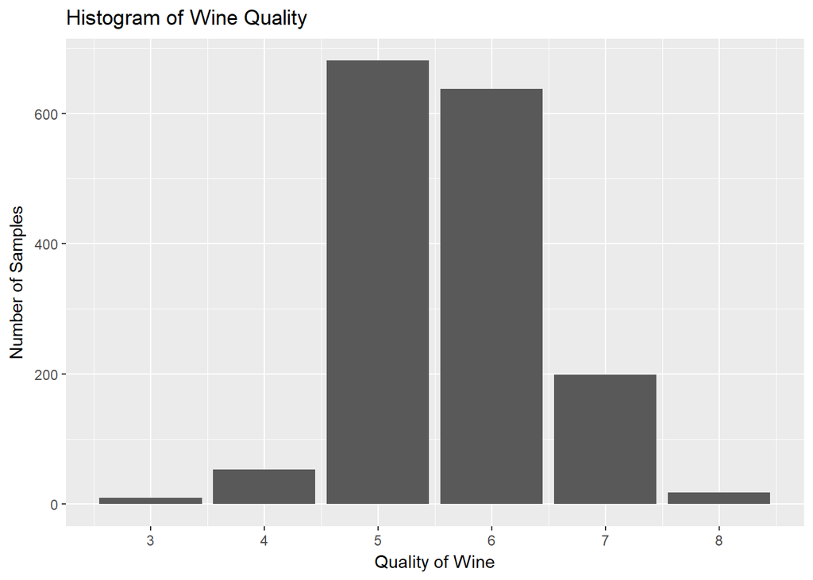

### Description One

The majority of wine samples have a medium quality of 5 to 6 which makes it  
difficult to build a reliable model since the samples for both high and low  
quality wines are low in count.

### Plot Two

[figure not shown]

### Description Two

Alcohol has the strongest correlation to wine quality as observed by the  
linearally fitted model

### Plot Three

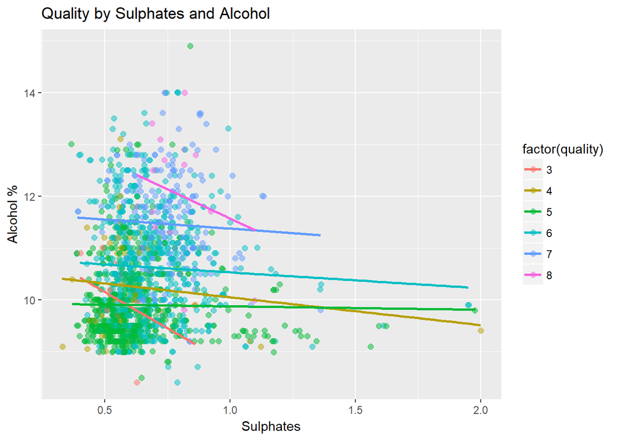

```r
ggplot(aes(sulphates, alcohol, color = factor(quality)),
       data = red_wine) +
  geom_jitter(size = 2, alpha = 1/2) +
  geom_smooth(method = "lm", se = FALSE,size=1) +
  labs(x = "Sulphates",
       y = "Alcohol %",
       title = "Quality by Sulphates and Alcohol")
```

# Reflection

## Recommendation

The data needs to be expanded to include more sample for the low quality and  
high quality wines (which are rare in provided data) for better understanding  
of the factors affecting the quality and also for better quality prediction.